# Titanic Survival Prediction : Life Goes on, Until Iceberg Come

FADHIL

10/10/2022

# Background

The sinking of the Titanic is one of the most infamous shipwrecks in history.

On April 15, 1912, during her maiden voyage, the widely considered “unsinkable” RMS Titanic sank after colliding with an iceberg. Unfortunately, there weren’t enough lifeboats for everyone onboard, resulting in the death of 1502 out of 2224 passengers and crew.

While there was some element of luck involved in surviving, it seems some groups of people were more likely to survive than others.

In this challenge, we ask you to build a predictive model that answers the question: “what sorts of people were more likely to survive?” using passenger data (ie name, age, gender, socio-economic class, etc).

# Data Set Reference

https://www.kaggle.com/c/titanic/

# The Code

## Reading Dataset

Let’s start by reading data train in the ‘titanic’ dataset and check the frame:

```r
titanic <- read.csv("train.csv")
head(titanic)
```

|  | PassengerId | Survived | Pclass | Name | Sex | Age | SibSp | Parch | Ticket | Fare | Cabin | Embarked |
| --- | --- | --- | --- | --- | --- | --- | --- | --- | --- | --- | --- | --- |
| 1 | 1 | 0 | 3 | Braund, Mr. Owen Harris | male | 22 | 1 | 0 | A/5 21171 | 7.2500 |  | S |
| 2 | 2 | 1 | 1 | Cumings, Mrs. John Bradley (Florence Briggs Thayer) | female | 38 | 1 | 0 | PC 17599 | 71.2833 | C85 | C |
| 3 | 3 | 1 | 3 | Heikkinen, Miss. Laina | female | 26 | 0 | 0 | STON/O2. 3101282 | 7.9250 |  | S |
| 4 | 4 | 1 | 1 | Futrelle, Mrs. Jacques Heath (Lily May Peel) | female | 35 | 1 | 0 | 113803 | 53.1000 | C123 | S |
| 5 | 5 | 0 | 3 | Allen, Mr. William Henry | male | 35 | 0 | 0 | 373450 | 8.0500 |  | S |
| 6 | 6 | 0 | 3 | Moran, Mr. James | male | NA | 0 | 0 | 330877 | 8.4583 |  | Q |

## Exploratory Data Analysis

### Data Inspection

Checking the data type

```r
summary(titanic)
```

```
##   PassengerId       Survived          Pclass          Name
##  Min.   :  1.0   Min.   :0.0000   Min.   :1.000   Length:891
##  1st Qu.:223.5   1st Qu.:0.0000   1st Qu.:2.000   Class :character
##  Median :446.0   Median :0.0000   Median :3.000   Mode  :character
##  Mean   :446.0   Mean   :0.3838   Mean   :2.309
##  3rd Qu.:668.5   3rd Qu.:1.0000   3rd Qu.:3.000
##  Max.   :891.0   Max.   :1.0000   Max.   :3.000
##
##      Sex                 Age            SibSp           Parch
##  Length:891         Min.   : 0.42   Min.   :0.000   Min.   :0.0000
##  Class :character   1st Qu.:20.12   1st Qu.:0.000   1st Qu.:0.0000
##  Mode  :character   Median :28.00   Median :0.000   Median :0.0000
##                     Mean   :29.70   Mean   :0.523   Mean   :0.3816
##                     3rd Qu.:38.00   3rd Qu.:1.000   3rd Qu.:0.0000
##                     Max.   :80.00   Max.   :8.000   Max.   :6.0000
##                     NA's   :177
##     Ticket               Fare           Cabin             Embarked
##  Length:891         Min.   :  0.00   Length:891         Length:891
##  Class :character   1st Qu.:  7.91   Class :character   Class :character
##  Mode  :character   Median : 14.45   Mode  :character   Mode  :character
##                     Mean   : 32.20
##                     3rd Qu.: 31.00
##                     Max.   :512.33
##
```

### Data Cleansing

Convert data type so we can calculate better

```r
titanic$Sex <- as.factor(titanic$Sex)
titanic$Embarked <- as.factor(titanic$Embarked)
```

check if there is/are missing value(s) in data frame

```r
anyNA(titanic)
```

```
## [1] TRUE
```

Check total missing value in every columns

```r
colSums(is.na(titanic))
```

```
## PassengerId    Survived      Pclass        Name         Sex         Age
##           0           0           0           0           0         177
##       SibSp       Parch      Ticket        Fare       Cabin    Embarked
##           0           0           0           0           0           0
```

```r
mean_age <- mean(titanic$Age)
titanic$Age[is.na(titanic$Age)] <- mean_age
colSums(is.na(titanic))
```

```
## PassengerId    Survived      Pclass        Name         Sex         Age
##           0           0           0           0           0         177
##       SibSp       Parch      Ticket        Fare       Cabin    Embarked
##           0           0           0           0           0           0
```

### Aggregation an Plotting

#### Survivor by Sex

```r
agg_sex <- table(titanic$Survived, titanic$Sex)
prop.table(agg_sex)*100
```

```
##
##        female      male
##   0  9.090909 52.525253
##   1 26.150393 12.233446
```

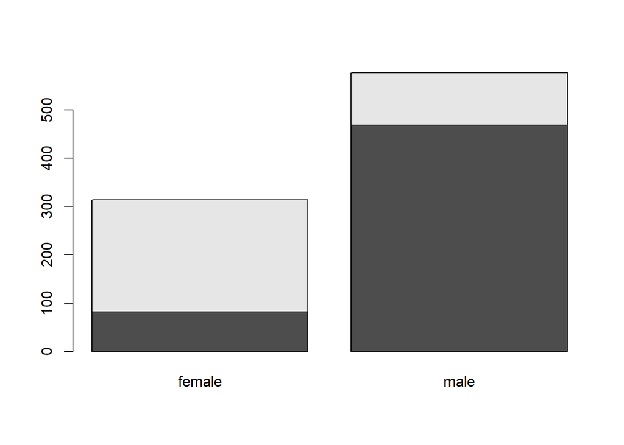

```r
barplot(agg_sex)
library(ggplot2)
```

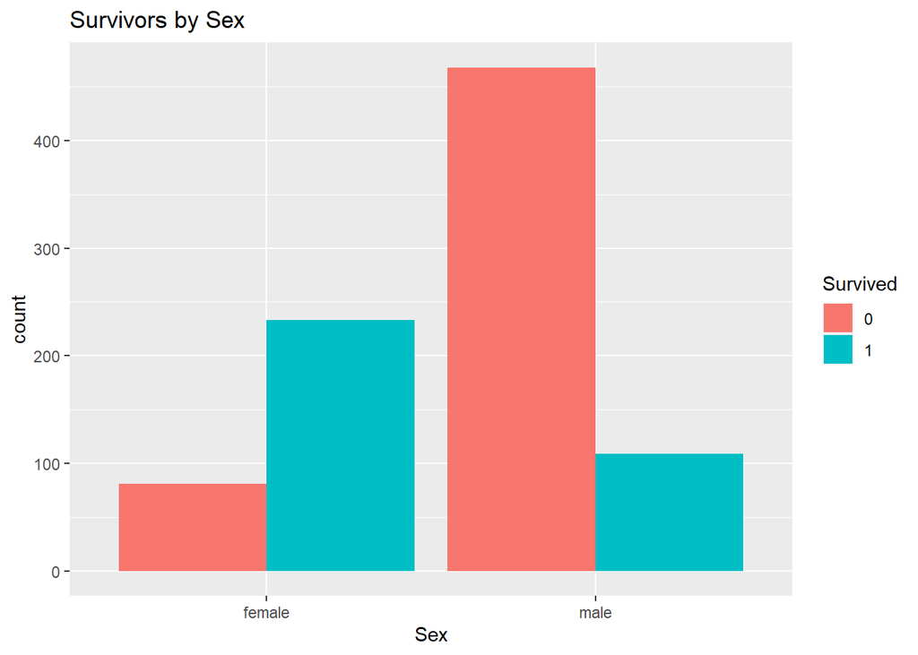

```r
ggplot(data=titanic, aes(Sex, fill = factor(Survived))) + geom_bar(stat = "count", position = "dodge") + xlab("Sex") + scale_fill_discrete(name = "Survived") + ggtitle("Survivors by Sex")
```

#### Survivor by Age

```r
agg_age <- table(titanic$Survived, titanic$Age)
prop.table(agg_age)*100
```

```
##
##          0.42      0.67      0.75      0.83      0.92         1         2
##   0 0.0000000 0.0000000 0.0000000 0.0000000 0.0000000 0.2801120 0.9803922
##   1 0.1400560 0.1400560 0.2801120 0.2801120 0.1400560 0.7002801 0.4201681
##
##             3         4         5         6         7         8         9
##   0 0.1400560 0.4201681 0.0000000 0.1400560 0.2801120 0.2801120 0.8403361
##   1 0.7002801 0.9803922 0.5602241 0.2801120 0.1400560 0.2801120 0.2801120
##
##            10        11        12        13        14      14.5        15
##   0 0.2801120 0.4201681 0.0000000 0.0000000 0.4201681 0.1400560 0.1400560
##   1 0.0000000 0.1400560 0.1400560 0.2801120 0.4201681 0.0000000 0.5602241
##
##            16        17        18        19        20      20.5        21
##   0 1.5406162 0.9803922 2.3809524 2.2408964 1.6806723 0.1400560 2.6610644
##   1 0.8403361 0.8403361 1.2605042 1.2605042 0.4201681 0.0000000 0.7002801
##
##            22        23      23.5        24      24.5        25        26
##   0 2.2408964 1.4005602 0.1400560 2.1008403 0.1400560 2.3809524 1.6806723
##   1 1.5406162 0.7002801 0.0000000 2.1008403 0.0000000 0.8403361 0.8403361
##
##            27        28      28.5        29        30      30.5        31
##   0 0.9803922 2.5210084 0.2801120 1.6806723 2.1008403 0.2801120 1.2605042
##   1 1.5406162 0.9803922 0.0000000 1.1204482 1.4005602 0.0000000 1.1204482
##
##            32      32.5        33        34      34.5        35        36
##   0 1.2605042 0.1400560 1.2605042 1.2605042 0.1400560 0.9803922 1.5406162
##   1 1.2605042 0.1400560 0.8403361 0.8403361 0.0000000 1.5406162 1.5406162
##
##          36.5        37        38        39        40      40.5        41
##   0 0.1400560 0.7002801 0.8403361 1.2605042 0.9803922 0.2801120 0.5602241
##   1 0.0000000 0.1400560 0.7002801 0.7002801 0.8403361 0.0000000 0.2801120
##
##            42        43        44        45      45.5        46        47
##   0 0.9803922 0.5602241 0.8403361 0.9803922 0.2801120 0.4201681 1.1204482
##   1 0.8403361 0.1400560 0.4201681 0.7002801 0.0000000 0.0000000 0.1400560
##
##            48        49        50        51        52        53        54
##   0 0.4201681 0.2801120 0.7002801 0.7002801 0.4201681 0.0000000 0.7002801
##   1 0.8403361 0.5602241 0.7002801 0.2801120 0.4201681 0.1400560 0.4201681
##
##            55      55.5        56        57        58        59        60
##   0 0.1400560 0.1400560 0.2801120 0.2801120 0.2801120 0.2801120 0.2801120
##   1 0.1400560 0.0000000 0.2801120 0.0000000 0.4201681 0.0000000 0.2801120
##
##            61        62        63        64        65        66        70
##   0 0.4201681 0.2801120 0.0000000 0.2801120 0.4201681 0.1400560 0.2801120
##   1 0.0000000 0.2801120 0.2801120 0.0000000 0.0000000 0.0000000 0.0000000
##
##          70.5        71        74        80
##   0 0.1400560 0.2801120 0.1400560 0.0000000
##   1 0.0000000 0.0000000 0.0000000 0.1400560
```

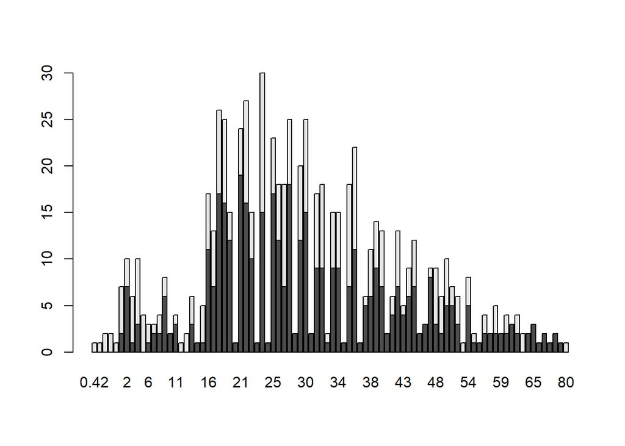

```r
barplot(agg_age)
```

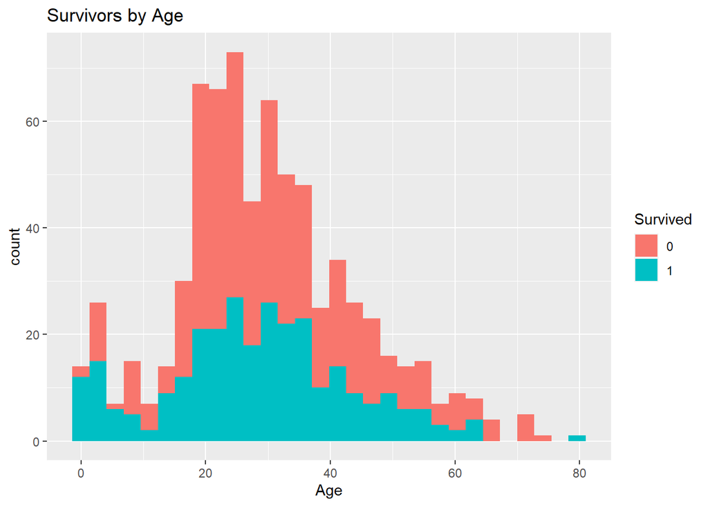

```r
ggplot(data=titanic, aes(Age, fill = factor(Survived))) + geom_histogram(bins = 30) + xlab("Age") + scale_fill_discrete(name = "Survived") + ggtitle("Survivors by Age")
```

#### Survivors by Number of Siblings

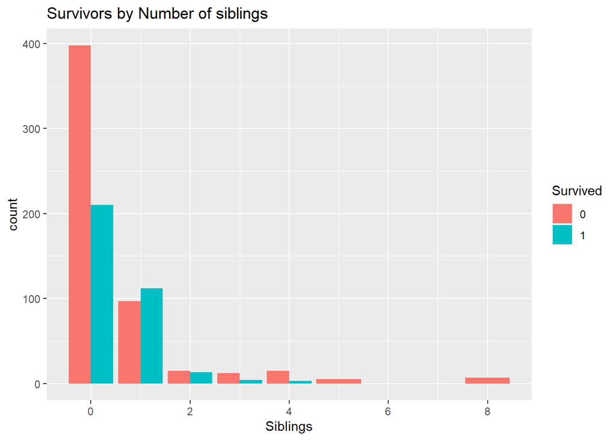

```r
ggplot(data=titanic, aes(SibSp, fill = factor(Survived))) + geom_bar(stat = "count", position = "dodge") + xlab("Siblings") + scale_fill_discrete(name = "Survived") + ggtitle("Survivors by Number of siblings")
```

#### Survivors by Number of Parents or Children

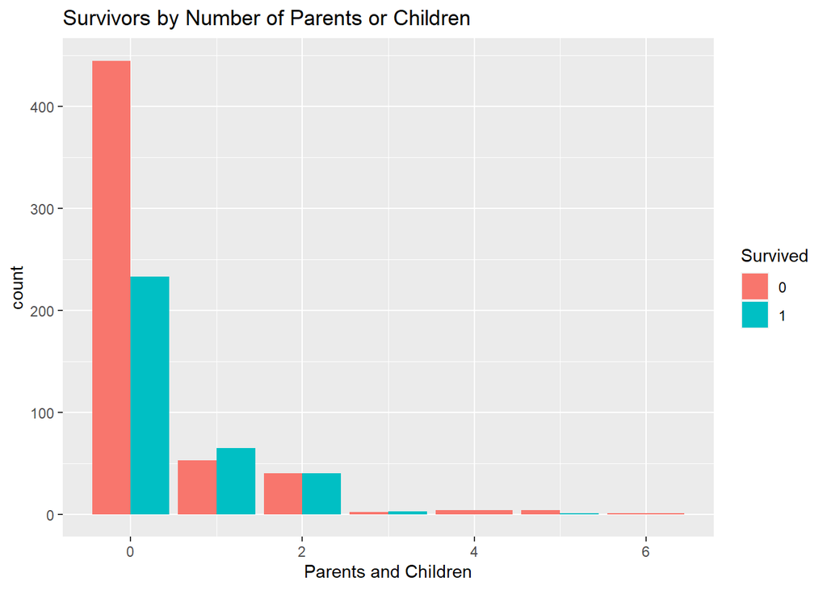

```r
ggplot(data=titanic, aes(Parch, fill = factor(Survived))) + geom_bar(stat = "count", position = "dodge") + xlab("Parents and Children") + scale_fill_discrete(name = "Survived") + ggtitle("Survivors by Number of Parents or Children")
```

#### Survivors by Family Members

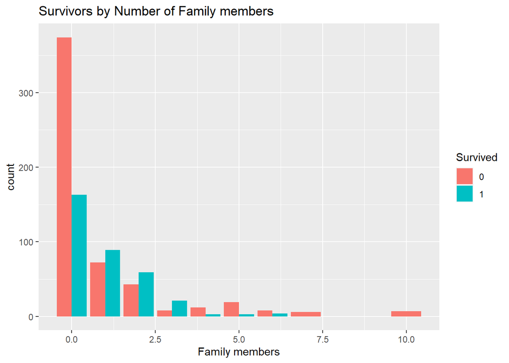

```r
ggplot(data=titanic, aes(Parch+SibSp, fill = factor(Survived))) + geom_bar(stat = "count", position = "dodge") + xlab("Family members") + scale_fill_discrete(name = "Survived") + ggtitle("Survivors by Number of Family members")
```

#### Survivors by Passengers Class

[figure not shown]

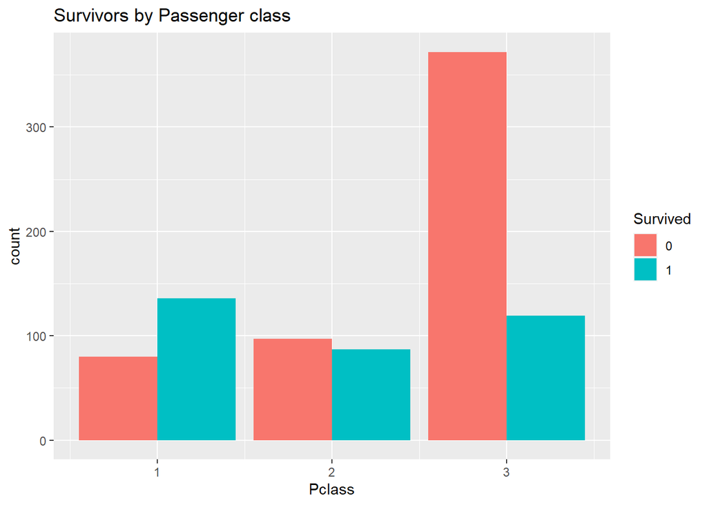

#### Survivors by Ticket Fare

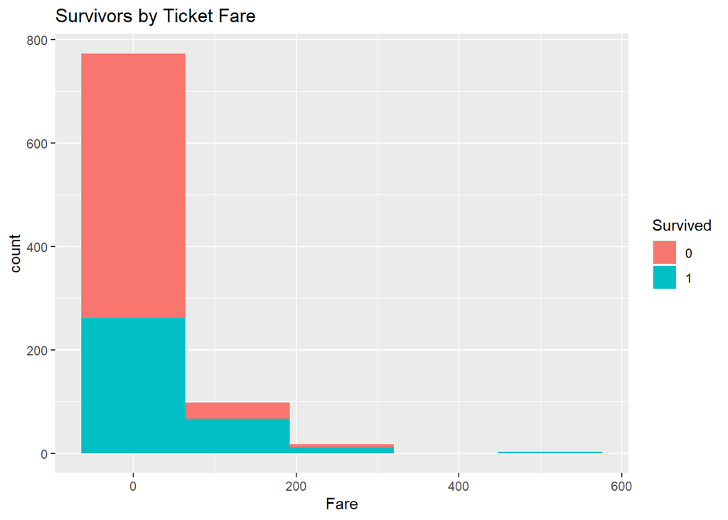

```r
ggplot(data=titanic, aes(Fare, fill = factor(Survived))) + geom_histogram(bins = 5) + xlab("Fare") + scale_fill_discrete(name = "Survived") + ggtitle("Survivors by Ticket Fare")
```

#### Summary Probability

```r
library(gtsummary)
train2 <- titanic %>% select(Survived, Sex, Pclass, SibSp, Parch, Embarked)
train2 %>% tbl_summary(by = Survived)
```

| **Characteristic** | **0**, N = 549<sup>1</sup> | **1**, N = 342<sup>1</sup> |
| --- | --- | --- |
| Sex |  |  |
| female | 81 (15%) | 233 (68%) |
| male | 468 (85%) | 109 (32%) |
| Pclass |  |  |
| 1 | 80 (15%) | 136 (40%) |
| 2 | 97 (18%) | 87 (25%) |
| 3 | 372 (68%) | 119 (35%) |
| SibSp |  |  |
| 0 | 398 (72%) | 210 (61%) |
| 1 | 97 (18%) | 112 (33%) |
| 2 | 15 (2.7%) | 13 (3.8%) |
| 3 | 12 (2.2%) | 4 (1.2%) |
| 4 | 15 (2.7%) | 3 (0.9%) |
| 5 | 5 (0.9%) | 0 (0%) |
| 8 | 7 (1.3%) | 0 (0%) |
| Parch |  |  |
| 0 | 445 (81%) | 233 (68%) |
| 1 | 53 (9.7%) | 65 (19%) |
| 2 | 40 (7.3%) | 40 (12%) |
| 3 | 2 (0.4%) | 3 (0.9%) |
| 4 | 4 (0.7%) | 0 (0%) |
| 5 | 4 (0.7%) | 1 (0.3%) |
| 6 | 1 (0.2%) | 0 (0%) |
| Embarked |  |  |
|  | 0 (0%) | 2 (0.6%) |
| C | 75 (14%) | 93 (27%) |
| Q | 47 (8.6%) | 30 (8.8%) |
| S | 427 (78%) | 217 (63%) |

<sup>1</sup> n (%)